# Capstone Gnana Week 1&2

## Capstone Project - The Battle of the Neighborhoods (Week 1/2)

## ----------------------------------------------------------------------

## Introduction to the Business Problem

This project is aimed at finding an optimal neighborhood location for a restaurant. **Specifically, this report is to advice a Thai restaurant chain that is interested in opening an outlet in Toronto.**

In Canada, especially in Toronto, being a food capital of Canada, Thai food is becoming very popular.Thai food has a multi ethnic appeal. It is basically enjoyed by South East Asian, Chinese and Indian community which is a sizeable population in Toronto.The chefs of this chain can modify the basic curry local spices and understand the need for western tastes and modified the level of spices and hotness. This chain has several outlets in the USA running successfully and wants to start operations in Canada. In Toronto, there are several successful Thai restaurants already and the question to be answered is with regard to the choice of location to beat existing competition and yet be profitable. That is to be able to find new catchment areas with similar characteristics as that of locations corresponding to the existing competitors.

We will use our data science techniques to generate a few most promising neighborhoods based on this criteria.

## Data Section

Key data sets required to proceed with solution are:

1. Neighborhood details for Toronto. Web crawling to understand the Toronto neighbourhood preferences, demographics and its food industry. https://en.wikipedia.org/wiki/List_of_postal_codes_of_Canada:_M, will be scraped using the BeautifulSoup packageto get the basic neighborhood data (Canada Boroughs,Neighbourhood and Postal code) . This will be augmented by geographical coordinates (Lattitude and Longitude) using the data in the csv file : http://cocl.us/Geospatial_data
2. Venue details that includes Thai and non Thai restaurants. For this Foursqaure API Venues data will be used to pull 100 venues in each neighbourhood within a radius of 500m that will include the venue name, venue category, longitude and lattitude details.

Data analysis:

1. Basic clean up of the datasets will be performed to make it suitable for running any data science analytics
2. Neighborhoods will be clustered and analyzed to understand the spending patterns and restaurant density in general. Geographical proximity and its association with the demographics of the physical locations will be analyzed which will provide key pointers while recommending the location for Thai restaurants
3. Density and geospatial spread of the existing Thai restaurants will be analyzed on the map and superimposed on the neighborhood clusters.

```python
import numpy as np # library to handle data in a vectorized manner

import pandas as pd # library for data analsysis
pd.set_option('display.max_columns', None)
pd.set_option('display.max_rows', None)

import json # library to handle JSON files

!conda install -c conda-forge geopy --yes # uncomment this line if you haven't completed the Foursquare API lab
from geopy.geocoders import Nominatim # convert an address into latitude and longitude values

import requests # library to handle requests
from pandas.io.json import json_normalize # tranform JSON file into a pandas dataframe

# Matplotlib and associated plotting modules
import matplotlib.cm as cm
import matplotlib.colors as colors

# import k-means from clustering stage
from sklearn.cluster import KMeans

!conda install -c conda-forge folium=0.5.0 --yes # uncomment this line if you haven't completed the Foursquare API lab
import folium # map rendering library

!conda install -c anaconda beautifulsoup4 --yes

print('Libraries imported.')
```

[output not shown]

[output cut: 54 more lines]

[output not shown]

## 1. Download and Explore Dataset

```python
#### Scraping wikipedia data to get the list of Canada neighbourhoods
```

```python
from bs4 import BeautifulSoup
```

```python
html = "https://en.wikipedia.org/wiki/List_of_postal_codes_of_Canada:_M"

## use bs4 scraping content from url
response = requests.get(html)

html_soup = BeautifulSoup(response.text, 'html.parser')
type(html_soup)
```

```
bs4.BeautifulSoup
```

```python
pip install lxml
```

[output not shown]

```python
# get tables
table = html_soup.find_all('table')[0]
df = pd.read_html(str(table))[0]

# get a record from table
df.head()
```

|  | Postcode | Borough | Neighbourhood |
| --- | --- | --- | --- |
| 0 | M1A | Not assigned | Not assigned |
| 1 | M2A | Not assigned | Not assigned |
| 2 | M3A | North York | Parkwoods |
| 3 | M4A | North York | Victoria Village |
| 4 | M5A | Downtown Toronto | Harbourfront |

### 1. Cleaning the neighbourhood data

```python
## drop column which Borough is not assigned
df_bor = df[~df.Borough.isin(['Not assigned'])]

## combine same Postcode into one column
df_combine = df_bor.groupby(['Postcode','Borough'])['Neighbourhood'].apply(','.join).reset_index()

## assign same value of Borough to Neighbourhood which is not assigned
df_combine.loc[df_combine['Neighbourhood']=="Not assigned",'Neighbourhood'] = df_combine.loc[df_combine['Neighbourhood']=="Not assigned",'Borough']
df_combine.head()
```

|  | Postcode | Borough | Neighbourhood |
| --- | --- | --- | --- |
| 0 | M1B | Scarborough | Rouge,Malvern |
| 1 | M1C | Scarborough | Highland Creek,Rouge Hill,Port Union |
| 2 | M1E | Scarborough | Guildwood,Morningside,West Hill |
| 3 | M1G | Scarborough | Woburn |
| 4 | M1H | Scarborough | Cedarbrae |

```python
df_combine.shape
```

```
(103, 3)
```

### Assigning Latitude and Longitude to the neighbourhood data

```python
a = pd.read_csv('https://cocl.us/Geospatial_data')
gdf = pd.DataFrame(a)
```

```python
## assign lat,long to postcode dataframe
df_post = pd.merge(df_combine,gdf,how='left',left_on='Postcode',right_on='Postal Code')
df_post.drop('Postal Code',axis=1,inplace=True)
df_post.head()
```

|  | Postcode | Borough | Neighbourhood | Latitude | Longitude |
| --- | --- | --- | --- | --- | --- |
| 0 | M1B | Scarborough | Rouge,Malvern | 43.806686 | -79.194353 |
| 1 | M1C | Scarborough | Highland Creek,Rouge Hill,Port Union | 43.784535 | -79.160497 |
| 2 | M1E | Scarborough | Guildwood,Morningside,West Hill | 43.763573 | -79.188711 |
| 3 | M1G | Scarborough | Woburn | 43.770992 | -79.216917 |
| 4 | M1H | Scarborough | Cedarbrae | 43.773136 | -79.239476 |

```python
df_post.shape
```

```
(103, 5)
```

```python
address = 'Toronto, ON'

geolocator = Nominatim(user_agent="ny_explorer")
location = geolocator.geocode(address)
latitude = location.latitude
longitude = location.longitude
print('The geograpical coordinate of Toronto City are {}, {}.'.format(latitude, longitude))
```

```
The geograpical coordinate of Toronto City are 43.653963, -79.387207.
```

```python
# create map of Toronto using latitude and longitude values
map_toronto = folium.Map(location=[latitude, longitude], zoom_start=10)

# add markers to map
for lat, lng, borough, neighborhood in zip(df_post['Latitude'], df_post['Longitude'], df_post['Borough'], df_post['Neighbourhood']):
    label = '{}, {}'.format(neighborhood, borough)
    label = folium.Popup(label, parse_html=True)
    folium.CircleMarker(
        [lat, lng],
        radius=5,
        popup=label,
        color='blue',
        fill=True,
        fill_color='#3186cc',
        fill_opacity=0.7,
        parse_html=False).add_to(map_toronto)

map_toronto
```

[interactive chart not shown]

```python
#We are going to work with only the boroughs that contain the word "Toronto".

df_t = df_post[df_post['Borough'].str.contains("Toronto")].reset_index(drop=True)
df_t.head()
```

|  | Postcode | Borough | Neighbourhood | Latitude | Longitude |
| --- | --- | --- | --- | --- | --- |
| 0 | M4E | East Toronto | The Beaches | 43.676357 | -79.293031 |
| 1 | M4K | East Toronto | The Danforth West,Riverdale | 43.679557 | -79.352188 |
| 2 | M4L | East Toronto | The Beaches West,India Bazaar | 43.668999 | -79.315572 |
| 3 | M4M | East Toronto | Studio District | 43.659526 | -79.340923 |
| 4 | M4N | Central Toronto | Lawrence Park | 43.728020 | -79.388790 |

#### Define Foursquare Credentials and Version

```python
CLIENT_ID = 'YSH1ABHBNWGMJW4T5LP2ETHXS40D5TUBWJ1JFE4MLET2SITO' # your Foursquare ID
CLIENT_SECRET = 'GHCI4N3ONG5XOMAG3ETKE4DCO0KWN0YHAJOPI1XI1BM2BJAN' # your Foursquare Secret
VERSION = '20180605' # Foursquare API version

print('Your credentails:')
print('CLIENT_ID: ' + CLIENT_ID)
print('CLIENT_SECRET:' + CLIENT_SECRET)
```

```
Your credentails:
CLIENT_ID: YSH1ABHBNWGMJW4T5LP2ETHXS40D5TUBWJ1JFE4MLET2SITO
CLIENT_SECRET:GHCI4N3ONG5XOMAG3ETKE4DCO0KWN0YHAJOPI1XI1BM2BJAN
```

#### Let's explore the first neighborhood in our dataframe

```python
df_t.loc[0, 'Neighbourhood']
```

```
'The Beaches'
```

#### Get the neighborhood's latitude and longitude values.

```python
neighborhood_latitude = df_t.loc[0, 'Latitude'] # neighborhood latitude value
neighborhood_longitude = df_t.loc[0, 'Longitude'] # neighborhood longitude value

neighborhood_name = df_t.loc[0, 'Neighbourhood'] # neighborhood name

print('Latitude and longitude values of {} are {}, {}.'.format(neighborhood_name,
                                                               neighborhood_latitude,
                                                               neighborhood_longitude))
```

```
Latitude and longitude values of The Beaches are 43.67635739999999, -79.2930312.
```

#### Now, let's get the top 100 venues that are in The Beaches within a radius of 500 meters.

```python
LIMIT = 100 # limit of number of venues returned by Foursquare API

radius = 500 # define radius

# create URL
url = 'https://api.foursquare.com/v2/venues/explore?&client_id={}&client_secret={}&v={}&ll={},{}&radius={}&limit={}'.format(
    CLIENT_ID,
    CLIENT_SECRET,
    VERSION,
    neighborhood_latitude,
    neighborhood_longitude,
    radius,
    LIMIT)
url # display URL
```

```
'https://api.foursquare.com/v2/venues/explore?&client_id=YSH1ABHBNWGMJW4T5LP2ETHXS40D5TUBWJ1JFE4MLET2SITO&client_secret=GHCI4N3ONG5XOMAG3ETKE4DCO0KWN0YHAJOPI1XI1BM2BJAN&v=20180605&ll=43.67635739999999,-79.2930312&radius=500&limit=100'
```

```python
results = requests.get(url).json()
```

```python
# function that extracts the category of the venue
def get_category_type(row):
    try:
        categories_list = row['categories']
    except:
        categories_list = row['venue.categories']

    if len(categories_list) == 0:
        return None
    else:
        return categories_list[0]['name']

venues = results['response']['groups'][0]['items']

nearby_venues = json_normalize(venues) # flatten JSON

# filter columns
filtered_columns = ['venue.name', 'venue.categories', 'venue.location.lat', 'venue.location.lng']
nearby_venues =nearby_venues.loc[:, filtered_columns]

# filter the category for each row
nearby_venues['venue.categories'] = nearby_venues.apply(get_category_type, axis=1)

# clean columns
nearby_venues.columns = [col.split(".")[-1] for col in nearby_venues.columns]

nearby_venues.head()
```

|  | name | categories | lat | lng |
| --- | --- | --- | --- | --- |
| 0 | Glen Manor Ravine | Trail | 43.676821 | -79.293942 |
| 1 | The Big Carrot Natural Food Market | Health Food Store | 43.678879 | -79.297734 |
| 2 | Grover Pub and Grub | Pub | 43.679181 | -79.297215 |
| 3 | Upper Beaches | Neighborhood | 43.680563 | -79.292869 |

```python
print('{} venues were returned by Foursquare.'.format(nearby_venues.shape[0]))
```

```
4 venues were returned by Foursquare.
```

## 2. Exploring Neighborhoods in Toronto

```python
#function to repeat the same process to all the neighborhoods in Toronto
def getNearbyVenues(names, latitudes, longitudes, radius=500):

    venues_list=[]
    for name, lat, lng in zip(names, latitudes, longitudes):
        print(name)

        # create the API request URL
        url = 'https://api.foursquare.com/v2/venues/explore?&client_id={}&client_secret={}&v={}&ll={},{}&radius={}&limit={}'.format(
            CLIENT_ID,
            CLIENT_SECRET,
            VERSION,
            lat,
            lng,
            radius,
            LIMIT)

        # make the GET request
        results = requests.get(url).json()["response"]['groups'][0]['items']

        # return only relevant information for each nearby venue
        venues_list.append([(
            name,
            lat,
            lng,
            v['venue']['name'],
            v['venue']['location']['lat'],
            v['venue']['location']['lng'],
            v['venue']['categories'][0]['name']) for v in results])

    nearby_venues = pd.DataFrame([item for venue_list in venues_list for item in venue_list])
    nearby_venues.columns = ['Neighborhood',
                  'Neighborhood Latitude',
                  'Neighborhood Longitude',
                  'Venue',
                  'Venue Latitude',
                  'Venue Longitude',
                  'Venue Category']

    return(nearby_venues)
```

```python
# Using the above function on each neighborhood to create a new dataframe called toronto_venues
toronto_venues = getNearbyVenues(names=df_t['Neighbourhood'],
                                   latitudes=df_t['Latitude'],
                                   longitudes=df_t['Longitude']
                                  )
print(toronto_venues.shape)
toronto_venues.head()
```

```
The Beaches
The Danforth West,Riverdale
The Beaches West,India Bazaar
Studio District
Lawrence Park
Davisville North
North Toronto West
Davisville
Moore Park,Summerhill East
Deer Park,Forest Hill SE,Rathnelly,South Hill,Summerhill West
Rosedale
Cabbagetown,St. James Town
Church and Wellesley
Harbourfront,Regent Park
Ryerson,Garden District
St. James Town
Berczy Park
Central Bay Street
Adelaide,King,Richmond
Harbourfront East,Toronto Islands,Union Station
Design Exchange,Toronto Dominion Centre
Commerce Court,Victoria Hotel
Roselawn
Forest Hill North,Forest Hill West
The Annex,North Midtown,Yorkville
Harbord,University of Toronto
Chinatown,Grange Park,Kensington Market
CN Tower,Bathurst Quay,Island airport,Harbourfront West,King and Spadina,Railway Lands,South Niagara
Stn A PO Boxes 25 The Esplanade
First Canadian Place,Underground city
Christie
Dovercourt Village,Dufferin
Little Portugal,Trinity
Brockton,Exhibition Place,Parkdale Village
High Park,The Junction South
Parkdale,Roncesvalles
Runnymede,Swansea
Business Reply Mail Processing Centre 969 Eastern
(1715, 7)
```

|  | Neighborhood | Neighborhood Latitude | Neighborhood Longitude | Venue | Venue Latitude | Venue Longitude | Venue Category |
| --- | --- | --- | --- | --- | --- | --- | --- |
| 0 | The Beaches | 43.676357 | -79.293031 | Glen Manor Ravine | 43.676821 | -79.293942 | Trail |
| 1 | The Beaches | 43.676357 | -79.293031 | The Big Carrot Natural Food Market | 43.678879 | -79.297734 | Health Food Store |
| 2 | The Beaches | 43.676357 | -79.293031 | Grover Pub and Grub | 43.679181 | -79.297215 | Pub |
| 3 | The Beaches | 43.676357 | -79.293031 | Upper Beaches | 43.680563 | -79.292869 | Neighborhood |
| 4 | The Danforth West,Riverdale | 43.679557 | -79.352188 | Pantheon | 43.677621 | -79.351434 | Greek Restaurant |

```python
#Let's check the size of the resulting dataframe
print(toronto_venues.shape)
toronto_venues.head()
```

```
(1715, 7)
```

|  | Neighborhood | Neighborhood Latitude | Neighborhood Longitude | Venue | Venue Latitude | Venue Longitude | Venue Category |
| --- | --- | --- | --- | --- | --- | --- | --- |
| 0 | The Beaches | 43.676357 | -79.293031 | Glen Manor Ravine | 43.676821 | -79.293942 | Trail |
| 1 | The Beaches | 43.676357 | -79.293031 | The Big Carrot Natural Food Market | 43.678879 | -79.297734 | Health Food Store |
| 2 | The Beaches | 43.676357 | -79.293031 | Grover Pub and Grub | 43.679181 | -79.297215 | Pub |
| 3 | The Beaches | 43.676357 | -79.293031 | Upper Beaches | 43.680563 | -79.292869 | Neighborhood |
| 4 | The Danforth West,Riverdale | 43.679557 | -79.352188 | Pantheon | 43.677621 | -79.351434 | Greek Restaurant |

```python
#Let's check how many venues were returned for each neighborhood

toronto_venues.groupby('Neighborhood').count()
```

| Neighborhood | Neighborhood Latitude | Neighborhood Longitude | Venue | Venue Latitude | Venue Longitude | Venue Category |
| --- | --- | --- | --- | --- | --- | --- |
| Adelaide,King,Richmond | 100 | 100 | 100 | 100 | 100 | 100 |
| Berczy Park | 56 | 56 | 56 | 56 | 56 | 56 |
| Brockton,Exhibition Place,Parkdale Village | 23 | 23 | 23 | 23 | 23 | 23 |
| Business Reply Mail Processing Centre 969 Eastern | 18 | 18 | 18 | 18 | 18 | 18 |
| CN Tower,Bathurst Quay,Island airport,Harbourfront West,King and Spadina,Railway Lands,South Niagara | 16 | 16 | 16 | 16 | 16 | 16 |
| Cabbagetown,St. James Town | 42 | 42 | 42 | 42 | 42 | 42 |
| Central Bay Street | 87 | 87 | 87 | 87 | 87 | 87 |
| Chinatown,Grange Park,Kensington Market | 100 | 100 | 100 | 100 | 100 | 100 |
| Christie | 17 | 17 | 17 | 17 | 17 | 17 |
| Church and Wellesley | 87 | 87 | 87 | 87 | 87 | 87 |
| Commerce Court,Victoria Hotel | 100 | 100 | 100 | 100 | 100 | 100 |
| Davisville | 36 | 36 | 36 | 36 | 36 | 36 |
| Davisville North | 8 | 8 | 8 | 8 | 8 | 8 |
| Deer Park,Forest Hill SE,Rathnelly,South Hill,Summerhill West | 15 | 15 | 15 | 15 | 15 | 15 |
| Design Exchange,Toronto Dominion Centre | 100 | 100 | 100 | 100 | 100 | 100 |
| Dovercourt Village,Dufferin | 15 | 15 | 15 | 15 | 15 | 15 |
| First Canadian Place,Underground city | 100 | 100 | 100 | 100 | 100 | 100 |
| Forest Hill North,Forest Hill West | 4 | 4 | 4 | 4 | 4 | 4 |
| Harbord,University of Toronto | 36 | 36 | 36 | 36 | 36 | 36 |
| Harbourfront East,Toronto Islands,Union Station | 100 | 100 | 100 | 100 | 100 | 100 |
| Harbourfront,Regent Park | 52 | 52 | 52 | 52 | 52 | 52 |
| High Park,The Junction South | 24 | 24 | 24 | 24 | 24 | 24 |
| Lawrence Park | 4 | 4 | 4 | 4 | 4 | 4 |
| Little Portugal,Trinity | 64 | 64 | 64 | 64 | 64 | 64 |
| Moore Park,Summerhill East | 4 | 4 | 4 | 4 | 4 | 4 |
| North Toronto West | 25 | 25 | 25 | 25 | 25 | 25 |
| Parkdale,Roncesvalles | 15 | 15 | 15 | 15 | 15 | 15 |
| Rosedale | 4 | 4 | 4 | 4 | 4 | 4 |
| Roselawn | 1 | 1 | 1 | 1 | 1 | 1 |
| Runnymede,Swansea | 37 | 37 | 37 | 37 | 37 | 37 |
| Ryerson,Garden District | 100 | 100 | 100 | 100 | 100 | 100 |
| St. James Town | 100 | 100 | 100 | 100 | 100 | 100 |
| Stn A PO Boxes 25 The Esplanade | 97 | 97 | 97 | 97 | 97 | 97 |
| Studio District | 39 | 39 | 39 | 39 | 39 | 39 |
| The Annex,North Midtown,Yorkville | 22 | 22 | 22 | 22 | 22 | 22 |
| The Beaches | 4 | 4 | 4 | 4 | 4 | 4 |
| The Beaches West,India Bazaar | 21 | 21 | 21 | 21 | 21 | 21 |
| The Danforth West,Riverdale | 42 | 42 | 42 | 42 | 42 | 42 |

```python
#Unique venue categories in Toronto

print('There are {} uniques categories.'.format(len(toronto_venues['Venue Category'].unique())))
```

```
There are 237 uniques categories.
```

## 3. Analyze Each Neighborhood

```python
# one hot encoding
toronto_onehot = pd.get_dummies(toronto_venues[['Venue Category']], prefix="", prefix_sep="")

# add neighborhood column back to dataframe
toronto_onehot['Neighbourhood'] = toronto_venues['Neighborhood']

# move neighborhood column to the first column
fixed_columns = [toronto_onehot.columns[-1]] + list(toronto_onehot.columns[:-1])
toronto_onehot = toronto_onehot[fixed_columns]

toronto_onehot.head()
```

|  | Neighbourhood | Afghan Restaurant | Airport | Airport Food Court | Airport Gate | Airport Lounge | Airport Service | Airport Terminal | American Restaurant | Antique Shop | Aquarium | Art Gallery | Art Museum | Arts & Crafts Store | Asian Restaurant | Athletics & Sports | Auto Workshop | BBQ Joint | Baby Store | Bagel Shop | Bakery | Bank | Bar | Baseball Stadium | Basketball Stadium | Beach | Bed & Breakfast | Beer Bar | Beer Store | … |
| --- | --- | --- | --- | --- | --- | --- | --- | --- | --- | --- | --- | --- | --- | --- | --- | --- | --- | --- | --- | --- | --- | --- | --- | --- | --- | --- | --- | --- | --- | --- |
| 0 | The Beaches | 0 | 0 | 0 | 0 | 0 | 0 | 0 | 0 | 0 | 0 | 0 | 0 | 0 | 0 | 0 | 0 | 0 | 0 | 0 | 0 | 0 | 0 | 0 | 0 | 0 | 0 | 0 | 0 | … |
| 1 | The Beaches | 0 | 0 | 0 | 0 | 0 | 0 | 0 | 0 | 0 | 0 | 0 | 0 | 0 | 0 | 0 | 0 | 0 | 0 | 0 | 0 | 0 | 0 | 0 | 0 | 0 | 0 | 0 | 0 | … |
| 2 | The Beaches | 0 | 0 | 0 | 0 | 0 | 0 | 0 | 0 | 0 | 0 | 0 | 0 | 0 | 0 | 0 | 0 | 0 | 0 | 0 | 0 | 0 | 0 | 0 | 0 | 0 | 0 | 0 | 0 | … |
| 3 | The Beaches | 0 | 0 | 0 | 0 | 0 | 0 | 0 | 0 | 0 | 0 | 0 | 0 | 0 | 0 | 0 | 0 | 0 | 0 | 0 | 0 | 0 | 0 | 0 | 0 | 0 | 0 | 0 | 0 | … |
| 4 | The Danforth West,Riverdale | 0 | 0 | 0 | 0 | 0 | 0 | 0 | 0 | 0 | 0 | 0 | 0 | 0 | 0 | 0 | 0 | 0 | 0 | 0 | 0 | 0 | 0 | 0 | 0 | 0 | 0 | 0 | 0 | … |

```python
toronto_onehot.shape
```

```
(1715, 238)
```

```python
#Grouping rows by neighborhood and by taking the mean of the frequency of occurrence of each category
toronto_grouped = toronto_onehot.groupby('Neighbourhood').mean().reset_index()
```

```python
toronto_grouped.shape
```

```
(38, 238)
```

```python
#function to sort the venues in descending order
def return_most_common_venues(row, num_top_venues):
    row_categories = row.iloc[1:]
    row_categories_sorted = row_categories.sort_values(ascending=False)

    return row_categories_sorted.index.values[0:num_top_venues]
```

```python
#Dataframe for the top 10 venues for each neighborhood.

num_top_venues = 10

indicators = ['st', 'nd', 'rd']

# create columns according to number of top venues
columns = ['Neighbourhood']
for ind in np.arange(num_top_venues):
    try:
        columns.append('{}{} Most Common Venue'.format(ind+1, indicators[ind]))
    except:
        columns.append('{}th Most Common Venue'.format(ind+1))

# create a new dataframe
neighborhoods_venues_sorted = pd.DataFrame(columns=columns)
neighborhoods_venues_sorted['Neighbourhood'] = toronto_grouped['Neighbourhood']

for ind in np.arange(toronto_grouped.shape[0]):
    neighborhoods_venues_sorted.iloc[ind, 1:] = return_most_common_venues(toronto_grouped.iloc[ind, :], num_top_venues)

neighborhoods_venues_sorted.head()
```

|  | Neighbourhood | 1st Most Common Venue | 2nd Most Common Venue | 3rd Most Common Venue | 4th Most Common Venue | 5th Most Common Venue | 6th Most Common Venue | 7th Most Common Venue | 8th Most Common Venue | 9th Most Common Venue | 10th Most Common Venue |
| --- | --- | --- | --- | --- | --- | --- | --- | --- | --- | --- | --- |
| 0 | Adelaide,King,Richmond | Coffee Shop | Café | Bar | Thai Restaurant | Hotel | American Restaurant | Breakfast Spot | Restaurant | Steakhouse | Asian Restaurant |
| 1 | Berczy Park | Coffee Shop | Cocktail Bar | Café | Farmers Market | Steakhouse | Beer Bar | Bakery | Cheese Shop | Italian Restaurant | Seafood Restaurant |
| 2 | Brockton,Exhibition Place,Parkdale Village | Coffee Shop | Breakfast Spot | Café | Climbing Gym | Stadium | Burrito Place | Sandwich Place | Caribbean Restaurant | Restaurant | Yoga Studio |
| 3 | Business Reply Mail Processing Centre 969 Eastern | Light Rail Station | Yoga Studio | Auto Workshop | Garden Center | Garden | Fast Food Restaurant | Farmers Market | Comic Shop | Park | Gym / Fitness Center |
| 4 | CN Tower,Bathurst Quay,Island airport,Harbourf... | Airport Service | Airport Lounge | Airport Terminal | Boat or Ferry | Harbor / Marina | Sculpture Garden | Coffee Shop | Boutique | Bar | Airport Gate |

## 4. Cluster Neighborhoods

```python
#Let's create a new dataframe that includes the cluster as well as the top 10 venues for each neighborhood.
```

```python
kclusters = 5

toronto_grouped_clustering = toronto_grouped.drop('Neighbourhood', 1)

# run k-means clustering
kmeans = KMeans(n_clusters=kclusters, random_state=0).fit(toronto_grouped_clustering)

# check cluster labels generated for each row in the dataframe
kmeans.labels_[0:10]
```

```
array([0, 0, 0, 0, 0, 0, 0, 0, 0, 0], dtype=int32)
```

```python
#Let's create a new dataframe that includes the cluster as well as the top 10 venues for each neighborhood.

# add clustering labels
neighborhoods_venues_sorted.insert(0, 'Cluster Labels', kmeans.labels_)
```

```python
neighborhoods_venues_sorted.head()
```

|  | Cluster Labels | Neighbourhood | 1st Most Common Venue | 2nd Most Common Venue | 3rd Most Common Venue | 4th Most Common Venue | 5th Most Common Venue | 6th Most Common Venue | 7th Most Common Venue | 8th Most Common Venue | 9th Most Common Venue | 10th Most Common Venue |
| --- | --- | --- | --- | --- | --- | --- | --- | --- | --- | --- | --- | --- |
| 0 | 0 | Adelaide,King,Richmond | Coffee Shop | Café | Bar | Thai Restaurant | Hotel | American Restaurant | Breakfast Spot | Restaurant | Steakhouse | Asian Restaurant |
| 1 | 0 | Berczy Park | Coffee Shop | Cocktail Bar | Café | Farmers Market | Steakhouse | Beer Bar | Bakery | Cheese Shop | Italian Restaurant | Seafood Restaurant |
| 2 | 0 | Brockton,Exhibition Place,Parkdale Village | Coffee Shop | Breakfast Spot | Café | Climbing Gym | Stadium | Burrito Place | Sandwich Place | Caribbean Restaurant | Restaurant | Yoga Studio |
| 3 | 0 | Business Reply Mail Processing Centre 969 Eastern | Light Rail Station | Yoga Studio | Auto Workshop | Garden Center | Garden | Fast Food Restaurant | Farmers Market | Comic Shop | Park | Gym / Fitness Center |
| 4 | 0 | CN Tower,Bathurst Quay,Island airport,Harbourf... | Airport Service | Airport Lounge | Airport Terminal | Boat or Ferry | Harbor / Marina | Sculpture Garden | Coffee Shop | Boutique | Bar | Airport Gate |

```python
toronto_merged = df_t

# merge toronto_grouped with toronto_data to add latitude/longitude for each neighborhood
toronto_merged = toronto_merged.join(neighborhoods_venues_sorted.set_index('Neighbourhood'), on='Neighbourhood')

toronto_merged.head() # check the last columns!
```

|  | Postcode | Borough | Neighbourhood | Latitude | Longitude | Cluster Labels | 1st Most Common Venue | 2nd Most Common Venue | 3rd Most Common Venue | 4th Most Common Venue | 5th Most Common Venue | 6th Most Common Venue | 7th Most Common Venue | 8th Most Common Venue | 9th Most Common Venue | 10th Most Common Venue |
| --- | --- | --- | --- | --- | --- | --- | --- | --- | --- | --- | --- | --- | --- | --- | --- | --- |
| 0 | M4E | East Toronto | The Beaches | 43.676357 | -79.293031 | 4 | Health Food Store | Pub | Trail | Neighborhood | Event Space | Ethiopian Restaurant | Electronics Store | Falafel Restaurant | Eastern European Restaurant | Dessert Shop |
| 1 | M4K | East Toronto | The Danforth West,Riverdale | 43.679557 | -79.352188 | 0 | Greek Restaurant | Coffee Shop | Italian Restaurant | Ice Cream Shop | Furniture / Home Store | Bubble Tea Shop | Sports Bar | Juice Bar | Spa | Liquor Store |
| 2 | M4L | East Toronto | The Beaches West,India Bazaar | 43.668999 | -79.315572 | 0 | Park | Pizza Place | Fast Food Restaurant | Sushi Restaurant | Movie Theater | Ice Cream Shop | Fish & Chips Shop | Pub | Intersection | Italian Restaurant |
| 3 | M4M | East Toronto | Studio District | 43.659526 | -79.340923 | 0 | Café | Coffee Shop | Bakery | Italian Restaurant | American Restaurant | Sandwich Place | Bar | Stationery Store | Fish Market | Coworking Space |
| 4 | M4N | Central Toronto | Lawrence Park | 43.728020 | -79.388790 | 2 | Dim Sum Restaurant | Park | Swim School | Bus Line | Diner | Falafel Restaurant | Event Space | Ethiopian Restaurant | Electronics Store | Eastern European Restaurant |

```python
# Create map to visualize the clusters
map_clusters = folium.Map(location=[latitude, longitude], zoom_start=11)

# set color scheme for the clusters
x = np.arange(kclusters)
ys = [i + x + (i*x)**2 for i in range(kclusters)]
colors_array = cm.rainbow(np.linspace(0, 1, len(ys)))
rainbow = [colors.rgb2hex(i) for i in colors_array]

# add markers to the map
markers_colors = []
for lat, lon, poi, cluster in zip(toronto_merged['Latitude'], toronto_merged['Longitude'], toronto_merged['Neighbourhood'], toronto_merged['Cluster Labels']):
    label = folium.Popup(str(poi) + ' Cluster ' + str(cluster), parse_html=True)
    folium.CircleMarker(
        [lat, lon],
        radius=5,
        popup=label,
        color=rainbow[cluster-1],
        fill=True,
        fill_color=rainbow[cluster-1],
        fill_opacity=0.7).add_to(map_clusters)

map_clusters
```

[interactive chart not shown]

## 5. Examine Clusters

#### Cluster0

```python
toronto_merged.loc[toronto_merged['Cluster Labels'] == 0, toronto_merged.columns[[2] + list(range(5, toronto_merged.shape[1]))]]
```

|  | Neighbourhood | Cluster Labels | 1st Most Common Venue | 2nd Most Common Venue | 3rd Most Common Venue | 4th Most Common Venue | 5th Most Common Venue | 6th Most Common Venue | 7th Most Common Venue | 8th Most Common Venue | 9th Most Common Venue | 10th Most Common Venue |
| --- | --- | --- | --- | --- | --- | --- | --- | --- | --- | --- | --- | --- |
| 1 | The Danforth West,Riverdale | 0 | Greek Restaurant | Coffee Shop | Italian Restaurant | Ice Cream Shop | Furniture / Home Store | Bubble Tea Shop | Sports Bar | Juice Bar | Spa | Liquor Store |
| 2 | The Beaches West,India Bazaar | 0 | Park | Pizza Place | Fast Food Restaurant | Sushi Restaurant | Movie Theater | Ice Cream Shop | Fish & Chips Shop | Pub | Intersection | Italian Restaurant |
| 3 | Studio District | 0 | Café | Coffee Shop | Bakery | Italian Restaurant | American Restaurant | Sandwich Place | Bar | Stationery Store | Fish Market | Coworking Space |
| 5 | Davisville North | 0 | Clothing Store | Gym | Park | Breakfast Spot | Hotel | Sandwich Place | Asian Restaurant | Food & Drink Shop | Donut Shop | Discount Store |
| 6 | North Toronto West | 0 | Clothing Store | Coffee Shop | Sporting Goods Shop | Gift Shop | Ice Cream Shop | Mexican Restaurant | Diner | Dessert Shop | Cosmetics Shop | Bagel Shop |
| 7 | Davisville | 0 | Sandwich Place | Dessert Shop | Pizza Place | Coffee Shop | Gym | Café | Italian Restaurant | Sushi Restaurant | Pharmacy | Greek Restaurant |
| 9 | Deer Park,Forest Hill SE,Rathnelly,South Hill,... | 0 | Pub | Coffee Shop | Pizza Place | Light Rail Station | Sports Bar | Supermarket | Sushi Restaurant | Bagel Shop | Restaurant | Fried Chicken Joint |
| 11 | Cabbagetown,St. James Town | 0 | Coffee Shop | Restaurant | Pizza Place | Italian Restaurant | Pub | Bakery | Café | Breakfast Spot | Market | Snack Place |
| 12 | Church and Wellesley | 0 | Coffee Shop | Japanese Restaurant | Sushi Restaurant | Gay Bar | Burger Joint | Restaurant | Ramen Restaurant | Gym | Gastropub | Hotel |
| 13 | Harbourfront,Regent Park | 0 | Coffee Shop | Park | Pub | Bakery | Café | Mexican Restaurant | Theater | Breakfast Spot | Gym / Fitness Center | Health Food Store |
| 14 | Ryerson,Garden District | 0 | Clothing Store | Coffee Shop | Cosmetics Shop | Middle Eastern Restaurant | Café | Sporting Goods Shop | Pizza Place | Fast Food Restaurant | Restaurant | Ramen Restaurant |
| 15 | St. James Town | 0 | Coffee Shop | Hotel | Café | Restaurant | Breakfast Spot | Clothing Store | Cosmetics Shop | Italian Restaurant | Bakery | Gastropub |
| 16 | Berczy Park | 0 | Coffee Shop | Cocktail Bar | Café | Farmers Market | Steakhouse | Beer Bar | Bakery | Cheese Shop | Italian Restaurant | Seafood Restaurant |
| 17 | Central Bay Street | 0 | Coffee Shop | Café | Ice Cream Shop | Italian Restaurant | Sandwich Place | Burger Joint | Chinese Restaurant | Japanese Restaurant | Salad Place | Bubble Tea Shop |
| 18 | Adelaide,King,Richmond | 0 | Coffee Shop | Café | Bar | Thai Restaurant | Hotel | American Restaurant | Breakfast Spot | Restaurant | Steakhouse | Asian Restaurant |
| 19 | Harbourfront East,Toronto Islands,Union Station | 0 | Coffee Shop | Hotel | Aquarium | Café | Fried Chicken Joint | Italian Restaurant | Brewery | Restaurant | Scenic Lookout | Sports Bar |
| 20 | Design Exchange,Toronto Dominion Centre | 0 | Coffee Shop | Café | Hotel | Restaurant | American Restaurant | Gastropub | Bar | Seafood Restaurant | Italian Restaurant | Deli / Bodega |
| 21 | Commerce Court,Victoria Hotel | 0 | Coffee Shop | Hotel | Café | Restaurant | American Restaurant | Seafood Restaurant | Steakhouse | Italian Restaurant | Gym | Gastropub |
| 23 | Forest Hill North,Forest Hill West | 0 | Mexican Restaurant | Trail | Sushi Restaurant | Jewelry Store | Yoga Studio | Diner | Falafel Restaurant | Event Space | Ethiopian Restaurant | Electronics Store |
| 24 | The Annex,North Midtown,Yorkville | 0 | Sandwich Place | Café | Coffee Shop | Pizza Place | Indian Restaurant | Pharmacy | Convenience Store | Cosmetics Shop | Pub | Burger Joint |
| 25 | Harbord,University of Toronto | 0 | Café | Bar | Italian Restaurant | Japanese Restaurant | Bookstore | Restaurant | Bakery | Poutine Place | Beer Bar | Beer Store |
| 26 | Chinatown,Grange Park,Kensington Market | 0 | Bar | Chinese Restaurant | Vegetarian / Vegan Restaurant | Café | Bakery | Coffee Shop | Mexican Restaurant | Vietnamese Restaurant | Dumpling Restaurant | Gaming Cafe |
| 27 | CN Tower,Bathurst Quay,Island airport,Harbourf... | 0 | Airport Service | Airport Lounge | Airport Terminal | Boat or Ferry | Harbor / Marina | Sculpture Garden | Coffee Shop | Boutique | Bar | Airport Gate |
| 28 | Stn A PO Boxes 25 The Esplanade | 0 | Coffee Shop | Café | Restaurant | Italian Restaurant | Seafood Restaurant | Cocktail Bar | Hotel | Beer Bar | Bakery | Cosmetics Shop |
| 29 | First Canadian Place,Underground city | 0 | Coffee Shop | Café | Hotel | Restaurant | Steakhouse | Gastropub | Bar | American Restaurant | Deli / Bodega | Gym |
| 30 | Christie | 0 | Grocery Store | Café | Park | Candy Store | Convenience Store | Baby Store | Coffee Shop | Italian Restaurant | Diner | Athletics & Sports |
| 31 | Dovercourt Village,Dufferin | 0 | Pharmacy | Bakery | Supermarket | Bank | Pet Store | Bar | Gym / Fitness Center | Park | Brewery | Café |
| 32 | Little Portugal,Trinity | 0 | Bar | Coffee Shop | Asian Restaurant | Men's Store | New American Restaurant | Bakery | Cocktail Bar | Pizza Place | Café | French Restaurant |
| 33 | Brockton,Exhibition Place,Parkdale Village | 0 | Coffee Shop | Breakfast Spot | Café | Climbing Gym | Stadium | Burrito Place | Sandwich Place | Caribbean Restaurant | Restaurant | Yoga Studio |
| 34 | High Park,The Junction South | 0 | Mexican Restaurant | Café | Bar | Thai Restaurant | Speakeasy | Furniture / Home Store | Bookstore | Fast Food Restaurant | Park | Flea Market |
| 35 | Parkdale,Roncesvalles | 0 | Breakfast Spot | Gift Shop | Bookstore | Bank | Dog Run | Bar | Italian Restaurant | Dessert Shop | Restaurant | Eastern European Restaurant |
| 36 | Runnymede,Swansea | 0 | Sushi Restaurant | Café | Coffee Shop | Italian Restaurant | Restaurant | Pizza Place | Bar | Diner | Food | Fish & Chips Shop |
| 37 | Business Reply Mail Processing Centre 969 Eastern | 0 | Light Rail Station | Yoga Studio | Auto Workshop | Garden Center | Garden | Fast Food Restaurant | Farmers Market | Comic Shop | Park | Gym / Fitness Center |

##### Cluster0 seems to have venues that are popular in the busy areas as is probably marks the business district of Toronto with lots of cafes, pubs and light weight entertainment centers to suit the busy lifestyle of the working class.

This cluster also encompasses the bulk of Toronto neighbourhoods indicating the lifestyle or key characteristic of the city itself.

#### Cluster1

```python
toronto_merged.loc[toronto_merged['Cluster Labels'] == 1, toronto_merged.columns[[2] + list(range(5, toronto_merged.shape[1]))]]
```

|  | Neighbourhood | Cluster Labels | 1st Most Common Venue | 2nd Most Common Venue | 3rd Most Common Venue | 4th Most Common Venue | 5th Most Common Venue | 6th Most Common Venue | 7th Most Common Venue | 8th Most Common Venue | 9th Most Common Venue | 10th Most Common Venue |
| --- | --- | --- | --- | --- | --- | --- | --- | --- | --- | --- | --- | --- |
| 22 | Roselawn | 1 | Garden | Yoga Studio | Filipino Restaurant | Farmers Market | Falafel Restaurant | Event Space | Ethiopian Restaurant | Electronics Store | Eastern European Restaurant | Dumpling Restaurant |

#### Cluster2

```python
toronto_merged.loc[toronto_merged['Cluster Labels'] == 2, toronto_merged.columns[[2] + list(range(5, toronto_merged.shape[1]))]]
```

|  | Neighbourhood | Cluster Labels | 1st Most Common Venue | 2nd Most Common Venue | 3rd Most Common Venue | 4th Most Common Venue | 5th Most Common Venue | 6th Most Common Venue | 7th Most Common Venue | 8th Most Common Venue | 9th Most Common Venue | 10th Most Common Venue |
| --- | --- | --- | --- | --- | --- | --- | --- | --- | --- | --- | --- | --- |
| 4 | Lawrence Park | 2 | Dim Sum Restaurant | Park | Swim School | Bus Line | Diner | Falafel Restaurant | Event Space | Ethiopian Restaurant | Electronics Store | Eastern European Restaurant |

##### Cluster2 seems to have venues characteristic of people who want to enjoy peaceful and leisure living.

Is a residential locality surrounded by posh neighbourhoods. Is geographically toward the north, away from the key business district.

#### Cluster3

```python
toronto_merged.loc[toronto_merged['Cluster Labels'] == 3, toronto_merged.columns[[2] + list(range(5, toronto_merged.shape[1]))]]
```

|  | Neighbourhood | Cluster Labels | 1st Most Common Venue | 2nd Most Common Venue | 3rd Most Common Venue | 4th Most Common Venue | 5th Most Common Venue | 6th Most Common Venue | 7th Most Common Venue | 8th Most Common Venue | 9th Most Common Venue | 10th Most Common Venue |
| --- | --- | --- | --- | --- | --- | --- | --- | --- | --- | --- | --- | --- |
| 8 | Moore Park,Summerhill East | 3 | Playground | Park | Summer Camp | Tennis Court | Dessert Shop | Event Space | Ethiopian Restaurant | Electronics Store | Eastern European Restaurant | Dumpling Restaurant |
| 10 | Rosedale | 3 | Park | Playground | Trail | Dessert Shop | Falafel Restaurant | Event Space | Ethiopian Restaurant | Electronics Store | Eastern European Restaurant | Dumpling Restaurant |

##### Cluster3 seems like a zone inhabited with health conscious poeple.

Wiki notes on Moore park - "Moore Park is one of Toronto's most affluent neighbourhoods."

#### Cluster4

```python
toronto_merged.loc[toronto_merged['Cluster Labels'] == 4, toronto_merged.columns[[2] + list(range(5, toronto_merged.shape[1]))]]
```

|  | Neighbourhood | Cluster Labels | 1st Most Common Venue | 2nd Most Common Venue | 3rd Most Common Venue | 4th Most Common Venue | 5th Most Common Venue | 6th Most Common Venue | 7th Most Common Venue | 8th Most Common Venue | 9th Most Common Venue | 10th Most Common Venue |
| --- | --- | --- | --- | --- | --- | --- | --- | --- | --- | --- | --- | --- |
| 0 | The Beaches | 4 | Health Food Store | Pub | Trail | Neighborhood | Event Space | Ethiopian Restaurant | Electronics Store | Falafel Restaurant | Eastern European Restaurant | Dessert Shop |

### Finding top 10 common restaurant categories in Toronto

```python
t_venue_cat_common=toronto_venues.groupby(['Venue Category']).size().reset_index(name='count').sort_values('count', ascending=False)
t_res=t_venue_cat_common[t_venue_cat_common['Venue Category'].str.contains("Restaurant")].reset_index(drop=True)
t_res.head(10).plot('Venue Category', 'count', kind='bar', figsize=(8,4), width=.25,colormap='Paired')
```

[output not shown]

### Finding neighborhoods with high restaurant density in Toronto

```python
toronto_res=toronto_venues[toronto_venues['Venue Category'].str.contains("Restaurant")].reset_index(drop=True)
#toronto_thai
toronto_res_nei=toronto_res.groupby(['Neighborhood']).size().reset_index(name='count').sort_values('count', ascending=False)
toronto_res_nei
```

|  | Neighborhood | count |
| --- | --- | --- |
| 6 | Chinatown,Grange Park,Kensington Market | 33 |
| 0 | Adelaide,King,Richmond | 28 |
| 8 | Church and Wellesley | 28 |
| 9 | Commerce Court,Victoria Hotel | 26 |
| 15 | First Canadian Place,Underground city | 25 |
| 13 | Design Exchange,Toronto Dominion Centre | 24 |
| 27 | St. James Town | 24 |
| 26 | Ryerson,Garden District | 23 |
| 5 | Central Bay Street | 23 |
| 28 | Stn A PO Boxes 25 The Esplanade | 21 |
| 22 | Little Portugal,Trinity | 21 |
| 32 | The Danforth West,Riverdale | 15 |
| 18 | Harbourfront East,Toronto Islands,Union Station | 14 |
| 1 | Berczy Park | 11 |
| 25 | Runnymede,Swansea | 11 |
| 10 | Davisville | 10 |
| 17 | Harbord,University of Toronto | 10 |
| 29 | Studio District | 10 |
| 4 | Cabbagetown,St. James Town | 10 |
| 20 | High Park,The Junction South | 7 |
| 19 | Harbourfront,Regent Park | 6 |
| 12 | Deer Park,Forest Hill SE,Rathnelly,South Hill,... | 4 |
| 30 | The Annex,North Midtown,Yorkville | 4 |
| 24 | Parkdale,Roncesvalles | 4 |
| 2 | Brockton,Exhibition Place,Parkdale Village | 3 |
| 31 | The Beaches West,India Bazaar | 3 |
| 23 | North Toronto West | 3 |
| 7 | Christie | 2 |
| 3 | Business Reply Mail Processing Centre 969 Eastern | 2 |
| 16 | Forest Hill North,Forest Hill West | 2 |
| 11 | Davisville North | 1 |
| 21 | Lawrence Park | 1 |
| 14 | Dovercourt Village,Dufferin | 1 |

### Finding neighborhoods with Thai restaurants in Toronto

```python
toronto_thai=toronto_venues[toronto_venues['Venue Category'].str.contains("Thai Restaurant")].reset_index(drop=True)
#toronto_thai
toronto_thai_nei=toronto_thai.groupby(['Neighborhood']).size().reset_index(name='count').sort_values('count', ascending=False)
toronto_thai_nei
```

|  | Neighborhood | count |
| --- | --- | --- |
| 0 | Adelaide,King,Richmond | 4 |
| 5 | Commerce Court,Victoria Hotel | 2 |
| 8 | First Canadian Place,Underground city | 2 |
| 9 | High Park,The Junction South | 2 |
| 1 | Berczy Park | 1 |
| 2 | Cabbagetown,St. James Town | 1 |
| 3 | Central Bay Street | 1 |
| 4 | Church and Wellesley | 1 |
| 6 | Davisville | 1 |
| 7 | Design Exchange,Toronto Dominion Centre | 1 |
| 10 | Ryerson,Garden District | 1 |
| 11 | St. James Town | 1 |
| 12 | Stn A PO Boxes 25 The Esplanade | 1 |
| 13 | Studio District | 1 |

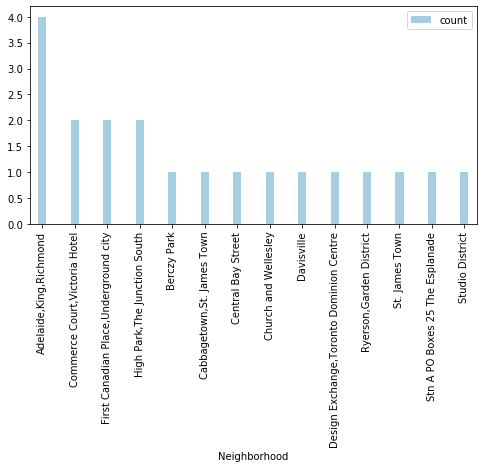

```python
toronto_thai_nei.plot('Neighborhood', 'count', kind='bar', figsize=(8,4), width=.25,colormap='Paired')
```

```python
# merge toronto_grouped with toronto_data to add latitude/longitude for each neighborhood
toronto_thai_merged = toronto_merged.join(toronto_thai_nei.set_index('Neighborhood'), on='Neighbourhood').sort_values('count', ascending=False)
toronto_thai_merged.dropna(axis=0, subset=('count', ), inplace=True)
toronto_thai_merged
```

|  | Postcode | Borough | Neighbourhood | Latitude | Longitude | Cluster Labels | 1st Most Common Venue | 2nd Most Common Venue | 3rd Most Common Venue | 4th Most Common Venue | 5th Most Common Venue | 6th Most Common Venue | 7th Most Common Venue | 8th Most Common Venue | 9th Most Common Venue | 10th Most Common Venue | count |
| --- | --- | --- | --- | --- | --- | --- | --- | --- | --- | --- | --- | --- | --- | --- | --- | --- | --- |
| 18 | M5H | Downtown Toronto | Adelaide,King,Richmond | 43.650571 | -79.384568 | 0 | Coffee Shop | Café | Bar | Thai Restaurant | Hotel | American Restaurant | Breakfast Spot | Restaurant | Steakhouse | Asian Restaurant | 4.0 |
| 21 | M5L | Downtown Toronto | Commerce Court,Victoria Hotel | 43.648198 | -79.379817 | 0 | Coffee Shop | Hotel | Café | Restaurant | American Restaurant | Seafood Restaurant | Steakhouse | Italian Restaurant | Gym | Gastropub | 2.0 |
| 29 | M5X | Downtown Toronto | First Canadian Place,Underground city | 43.648429 | -79.382280 | 0 | Coffee Shop | Café | Hotel | Restaurant | Steakhouse | Gastropub | Bar | American Restaurant | Deli / Bodega | Gym | 2.0 |
| 34 | M6P | West Toronto | High Park,The Junction South | 43.661608 | -79.464763 | 0 | Mexican Restaurant | Café | Bar | Thai Restaurant | Speakeasy | Furniture / Home Store | Bookstore | Fast Food Restaurant | Park | Flea Market | 2.0 |
| 3 | M4M | East Toronto | Studio District | 43.659526 | -79.340923 | 0 | Café | Coffee Shop | Bakery | Italian Restaurant | American Restaurant | Sandwich Place | Bar | Stationery Store | Fish Market | Coworking Space | 1.0 |
| 7 | M4S | Central Toronto | Davisville | 43.704324 | -79.388790 | 0 | Sandwich Place | Dessert Shop | Pizza Place | Coffee Shop | Gym | Café | Italian Restaurant | Sushi Restaurant | Pharmacy | Greek Restaurant | 1.0 |
| 11 | M4X | Downtown Toronto | Cabbagetown,St. James Town | 43.667967 | -79.367675 | 0 | Coffee Shop | Restaurant | Pizza Place | Italian Restaurant | Pub | Bakery | Café | Breakfast Spot | Market | Snack Place | 1.0 |
| 12 | M4Y | Downtown Toronto | Church and Wellesley | 43.665860 | -79.383160 | 0 | Coffee Shop | Japanese Restaurant | Sushi Restaurant | Gay Bar | Burger Joint | Restaurant | Ramen Restaurant | Gym | Gastropub | Hotel | 1.0 |
| 14 | M5B | Downtown Toronto | Ryerson,Garden District | 43.657162 | -79.378937 | 0 | Clothing Store | Coffee Shop | Cosmetics Shop | Middle Eastern Restaurant | Café | Sporting Goods Shop | Pizza Place | Fast Food Restaurant | Restaurant | Ramen Restaurant | 1.0 |
| 15 | M5C | Downtown Toronto | St. James Town | 43.651494 | -79.375418 | 0 | Coffee Shop | Hotel | Café | Restaurant | Breakfast Spot | Clothing Store | Cosmetics Shop | Italian Restaurant | Bakery | Gastropub | 1.0 |
| 16 | M5E | Downtown Toronto | Berczy Park | 43.644771 | -79.373306 | 0 | Coffee Shop | Cocktail Bar | Café | Farmers Market | Steakhouse | Beer Bar | Bakery | Cheese Shop | Italian Restaurant | Seafood Restaurant | 1.0 |
| 17 | M5G | Downtown Toronto | Central Bay Street | 43.657952 | -79.387383 | 0 | Coffee Shop | Café | Ice Cream Shop | Italian Restaurant | Sandwich Place | Burger Joint | Chinese Restaurant | Japanese Restaurant | Salad Place | Bubble Tea Shop | 1.0 |
| 20 | M5K | Downtown Toronto | Design Exchange,Toronto Dominion Centre | 43.647177 | -79.381576 | 0 | Coffee Shop | Café | Hotel | Restaurant | American Restaurant | Gastropub | Bar | Seafood Restaurant | Italian Restaurant | Deli / Bodega | 1.0 |
| 28 | M5W | Downtown Toronto | Stn A PO Boxes 25 The Esplanade | 43.646435 | -79.374846 | 0 | Coffee Shop | Café | Restaurant | Italian Restaurant | Seafood Restaurant | Cocktail Bar | Hotel | Beer Bar | Bakery | Cosmetics Shop | 1.0 |

```python
# Create map to superimpose Italian restaurants on the cluster map
map_clusters = folium.Map(location=[latitude, longitude], zoom_start=11)

# set color scheme for the clusters
x = np.arange(kclusters)
ys = [i + x + (i*x)**2 for i in range(kclusters)]
colors_array = cm.rainbow(np.linspace(0, 1, len(ys)))
rainbow = [colors.rgb2hex(i) for i in colors_array]

# add markers to the map
markers_colors = []
for lat, lon, poi, cluster in zip(toronto_merged['Latitude'], toronto_merged['Longitude'], toronto_merged['Neighbourhood'], toronto_merged['Cluster Labels']):
    label = folium.Popup(str(poi) + ' Cluster ' + str(cluster), parse_html=True)
    folium.CircleMarker(
        [lat, lon],
        radius=5,
        popup=label,
        color=rainbow[cluster-1],
        fill=True,
        fill_color=rainbow[cluster-1],
        fill_opacity=0.7).add_to(map_clusters)

# add the Thai restaurants as yellow circle markers
for lat, lng, label in zip(toronto_thai['Neighborhood Latitude'], toronto_thai['Neighborhood Longitude'], toronto_thai['Venue']):
    folium.features.CircleMarker(
        [lat, lng],
        radius=2,
        color='black',
        popup=label,
        fill = True,
        fill_color='yellow',
        fill_opacity=0.6
    ).add_to(map_clusters)

map_clusters
```

[interactive chart not shown]

**On the basis of the visual inspection of the existing Thai restaurants in Cluster0, any new restaurant can be positioned in the western Cluster0 neighborhoods ie in the area between High Park and Salad King which shares the characteristics of neighborhoods in which the restaurant business is thriving. Top picks are the neighborhoods of Dovercourt Village and Christie given the low restaurant density, competition is less in that area and hence can prove to be quite profitable.**